# Documentación Proyecto final

Felipe Gerard, Omar Díaz, Andrés Villaseñor

21 de mayo de 2015

## 0. Introducción

Las colecciones grandes de documentos pueden ser difíciles de aprovechar. Por ejemplo, si queremos que una o varias palabras aparezcan en el documento, podemos hacer un filtro simple. Sin embargo, si las palabras son (razonablemente) comunes, el query nos podría regresar un porcentaje importante de la colección de documentos, sobre todo si son muy largos. Algo más refinado que podríamos hacer sería por ejemplo usar el número de veces que aparecen las palabras deseadas, aunque esto favorecería documentos extensos y las palabras comunes.

En el presente trabajo minaremos una [colección de *abstracts*](https://archive.ics.uci.edu/ml/datasets/NSF+Research+Award+Abstracts+1990-2003) de 129,000 artículos ganadores de premios de la National Science Foundation (NSF) entre 1990 y 2003. El conjunto de datos está interesante porque provee las versiones cortas de los artículos, de modo que podemos leerlos y darnos una idea rápida de lo que trata cada artículo. En la página estaba la información en crudo (.txt) y ya lista para utilizar el método de bolsa de palabras. Preferimos utilizar la información cruda original para hacer el proceso desde la limpieza de los datos. El objetivo es realizar búsquedas temáticas inteligentes dentro de la colección, es decir, dado un conjunto de palabras clave, queremos obtener los artículos más relevantes. En la siguiente sección describiremos la teoría del método que utilizamos para mitigar los problemas descritos anteriormente.

## 1. Teoría

Como decíamos arriba, no basta con filtrar los artículos según la aparición de las palabras clave, ni tampoco un conteo simple. Lo que haremos será tomar en cuenta los conteos, pero usaremos técnicas para disminuir la importancia de la longitud de los documentos en cuestión y de la frecuencia de aparición de las palabras comunes.

Denotamos la frecuencia del término $w$ (puede ser una palabra o la raíz de una palabra obtenida con *stemming*) en el documento $d$ como $tf_{w,d}$. De manera natural, denotamos por $tf_d$ al vector de todas las frecuencias de los términos conocidos del documento $d$. Supongamos que queremos comparar los documentos $q$ y $d$. Un primer enfoque que podríamos utilizar sería usar la distancia coseno, que toma en cuenta únicamente la frecuencia relativa de las palabras dentro de los documentos:

$d_{coseno}(q,d) = \frac{tf_q \cdot tf_d}{\|tf_q\| \|tf_d\|}$

El problema con lo anterior es que las palabras comunes podrían tomar un papel protagónico y en nuestro caso compartir por ejemplo artículos o preposiciones no es muy interesante. Para mitigar esto utilizaremos la frecuencia inversa en documentos $idf_w$, definida para una palabra $w$. Si $N$ es el número total de documentos en la colección y $df_w$ es el número de documentos de la colección que contienen a $w$, entonces definimos la frecuencia inversa de documentos como sigue:

$idf_w = log(\frac{N}{df_w})$

Y entonces, en lugar de describir a $d$ por medio de $tf_d$, lo describimos por medio de $c_d$, donde

$c_{d,w} = idf_w \times tf_{d,w}$

Y así, calculamos la distancia entre dos documentos como la distancia coseno entre sus vectores característicos:

$d(q,d) = \frac{c_q \cdot c_d}{\|c_q\| \|c_d\|}$

La $idf_w$ es el logaritmo del inverso de la probabilidad de que el término $w$ aparezca en un documento elegido al azar. El efecto que esto tiene es que las palabras comunes casi no tendrán ningún efecto en la distancia, puesto que su probabilidad es cercana a 1 y por lo tanto su $idf$ es cercana a cero. Por el contrario, las palabras raras tendrán una probabilidad cercana a 0, por lo que su $idf$ será grande y contribuirán mucho. La razón detrás de hacer esto es que queremos que discriminen las palabras especiales o específicas a un contexto y no las genéricas. El esquema expuesto está escrito con mayor detalle en el libro [Mining of Massive Datasets](http://www.mmds.org), con el detalle de que ahí además normalizan $tf_w$ por la máxima frecuencia obtenida por el término en la colección de documentos.

## 2. Limpieza de la colección de abstracts

## 2.1. Descripción del proceso

La limpieza de los datos consiste en los siguientes pasos:

- **Conversión de archivos de texto a JSON** estructurado en *bash* (`abstract2json.sh`):

```r
    {
  "1":{
        "Titulo":{"Ejemplo de título"},
        "Fecha":{"2013-01-02"},
        "Abstract":{"Ejemplo de abstract"},
        ...
        },
    "2":{
        "Titulo":{"Ejemplo de otro título"},
        "Fecha":{"2003-03-02"},
        "Abstract":{"Ejemplo de otro abstract"},
        ...
        },
    ...
    }
```

- **Conversión de JSON** estructurado a data.frame de R para el análisis en *R* (`json2dataframe_abstracts.R`):
- **Texto –> JSON**

- **JSON –> data.frame**

Primero nos aseguramos de que el formato sea legible en *R*. Cuando no, utilizamos *Python* para limpiar el formato. Una vez habiendo leído la lista a *R* con la librería `jsonlite`, convertimos la lista recursiva a `data.frame`. Para ahorrar tiempo, utilizamos la función `mclapply` del paquete `parallel`. Finalmente, regresamos la puntuación a su forma original para que el texto recuperado sea legible.

## 2.2 Ejemplo

- **Texto original:**

```r
Title       : RFLP Patterns as a Measure of Diversity in Small Populations
Type        : Award
NSF Org     : MCB
Latest
Amendment
Date        : May 31,  1990
File        : a9000031

Award Number: 9000031
Award Instr.: Standard Grant
Prgm Manager: Maryanna P. Henkart
MCB  DIV OF MOLECULAR AND CELLULAR BIOSCIENCE
BIO  DIRECT FOR BIOLOGICAL SCIENCES
    Start Date  : June 1,  1990
Expires     : May 31,  1994        (Estimated)
    Expected
    Total Amt.  : $300000             (Estimated)
Investigator: Marcia M. Miller mamiller@coh.org  (Principal Investigator current)
    Sponsor     : Beckman Res Inst Cty Hope
    1500 E. Duarte Road
    Duarte, CA  910103000    /   -

    NSF Program : 1114      CELL BIOLOGY
    Fld Applictn: 0000099   Other Applications NEC
    61        Life Science Biological
    Program Ref : 9285,
    Abstract    :

    Studies of chickens have provided serological and nucleic acid
    probes useful in defining the major histocompatibility complex
    (MHC) in other avian species.  Methods used in detecting genetic
    diversity at loci within the MHC of chickens and mammals will be
    applied to determining the extent of MHC polymorphism within
    small populations of ring-necked pheasants, wild turkeys, cranes,
    Andean condors and other species.  The knowledge and expertise
    gained from working with the MHC of the chicken should make for
    rapid progress in defining the polymorphism of the MHC in these
    species and in detecting the polymorphism of MHC gene pool within
    small wild and captive populations of these birds.

    Genes within the major histocompatibility complex (MHC) are known
    to encode molecules that provide the context for recognition of
    foreign antigens by the immune system.  Whether a given animal is
    able to mount an immune response to the challenge of a pathogen
    is determined, in part, by the allelic makeup of its MHC.  In
    many species, an unusually high degree of polymorphism is
    maintained at multiple loci within the MHC in freely breeding
    populations.  The allelic pool within a population presumably
    provides diversity upon which to draw in the face of
    environmental challenge.  The objective of the proposed research
    is to extend ongoing studies of the MHC of domesticated fowl to
    include avian species experiencing severe reduction in population
    size.  Knowledge of the MHC gene pool within populations and of
    the haplotypes of individual animals may be useful in the
    husbandry of species requiring intervention for their
    preservation.
```

- **JSON**

```r
"51758":{
    "Title":"RFLP Patterns as a Measure of Diversity in Small Populations",
    "Date":"May 31<coma> 1990",
    "Award Number":"9000031",
    "Investigator":"Marcia M<punto> Miller mamillercoh<punto>org <abre_parent>Principal
    Investigator current<cierra_parent>",
    "Sponsor":"Beckman Res Inst Cty Hope<br> 1500 E<punto> Duarte Road<br> Duarte<coma>
    CA 910103000 <diagonal> <guion><br>",
    "Fld Applictn":"0000099 Other Applications NEC <br> 61 Life Science Biological",
    "Abstract":"<br> <br> Studies of chickens have provided serological and nucleic
    acid <br> probes useful in defining the major histocompatibility complex <br>
    <abre_parent> MHC<cierra_parent> in other avian species<punto> Methods used in
    detecting genetic <br> diversity at loci within the MHC of chickens and mammals will
    be <br> applied to determining the extent of MHC polymorphism within <br> small
    populations of ring<guion>necked pheasants <coma> wild turkeys<coma> cranes<coma> <br>
    Andean condors and other species<punto> The knowledge and expertise <br> gained from
    working with the MHC of the chicken should make for <br> rapid progress in defining
    the polymorphism of the MHC in these <br> species and in detecting the polymorphism
    of MHC gene pool within <br> small wild and captive populations of
    these birds<punto> <br> <br> Genes within the major histocompatibility complex
    <abre_parent> MHC<cierra_parent> are known <br> to encode molecules that provide
    the context for recognition of <br> foreign antigens by the immune system<punto>
    Whether a given animal is <br> able to mount an immune response to the challenge
    of a pathogen <br> is determined<coma> in part<coma> by the allelic makeup of its
    MHC<punto> In <br> many species<coma> an unusually high degree of polymorphism
    is <br> maintained at multiple loci within the MHC in freely breeding <br>
    populations<punto> The allelic pool within a population presumably <br>
    provides diversity upon  which to draw in the face of <br>
    environmental challenge<punto> The objective of the proposed research <br>
    is to extend ongoing studies of the MHC of domesticated fowl to <br>
    include avian species experiencing severe reduction in population <br>
    size<punto> Knowledge ofthe MHC gene pool within populations and of <br>
    the haplotypes of individual animals may be useful in the <br>
    husbandry of species requiring intervention for their <br>
    preservation<punto><br>"
}
```

### 3. Data Frame

Tiene las columnas del JSON anterior pero en versión y la puntuación en formato normal. No incluimos el ejemplo porque el formato no es práctico.

### 4. Implementación del modelo

Una vez con los datos limpios como se mencionó anteriormente, procedemos a implementar el modelo. Este va a buscar la información reelevante a un tema o palabras, y va a mezclar dos criterios de selección (**título** y **abstract**) de tal manera que el usuario en la aplicación de shiny va a poder escoger a que concepto le quiere dar más peso mediante una variable dinámica *“alpha”*.

Escogemos el query y lo limpiamos para que sea totalmente homogeneo al corpus de los datos que más adelante veremos.

```r
#Las librerías utilizadas son las siguientes:
library(Matrix)
library(dplyr)
library(tm)
library(slam)
library(Rstem)
library(ggplot2)
library(wordcloud)
library(knitr)

#carga de datos
#load('abstracts_clean.Rdata')
abstracts2 <- as.data.frame(abstracts2)


########################################################  Query #######################################################

query <- 'Polarity Transistion Studies in the Waianae Volcano: From the Gilbert-Gauss to the Upper Kaena Reversals'
#query <- 'Markov Chain Monte Carlo'


#limpieza del query
query.limp <- Corpus(VectorSource(query))
query.limp <- tm_map(query.limp,function(x){
  q1 <- gsub('[-]|<br>',' ',x)
  gsub('[()]|[.,;:`"*#&/><]|[\\\']|[]\\[]','',q1)
})
query.limp <- tm_map(query.limp,removeWords,stopwords("english"))
query.limp <- tm_map(query.limp, function(x) stripWhitespace(x) %>% tolower)
query.limp <- tm_map(query.limp,function(x){
  z <- strsplit(x, " +")[[1]]
  z.stem <- wordStem(z, language="english")
  PlainTextDocument(paste(z.stem, collapse=" "))
})
```

Tras la limpieza de los datos mencionada anteriormente, tenemos que aún en necesario tranformarlos y quitar los datos faltantes o datos que tengan alguna imperfección.

```r
###################################  limpieza de la informacion y creacion del corpus (datos) ##################################

# filtramos cosas feas en abstract y title
d <- abstracts2 %>%
  filter(grepl('Presidential Awardee',Title)=='FALSE') %>% #815
  filter(grepl('Not Available',Abstract)=='FALSE') %>% #1267
  filter(Title != '') %>% #8
  filter(Abstract != '' ) %>% #2180
  filter(grepl('-----------------------------------------------------------------------',Abstract)=='FALSE') %>%
  mutate(id=row_number()) %>%
  dplyr::select(id,Title,Abstract,Fld.Applictn,Date,Sponsor,Investigator,Award.Number)

d_fin <- d
```

Hacemos el corpus para los títulos.

```r
################################################  Análisis por Título (title) #####################################


# creamos el corpus y limpiamos caracteres especiales del titulo
corpus.title <- Corpus(VectorSource(d$Title))


corp.1 <- tm_map(corpus.title,function(x){
  c1 <- gsub('[-]|<br>',' ',x)
  gsub('[()]|[.,;:`"*#&/><]|[\\\']|[]\\[]','',c1)
})
corp.1 <- tm_map(corp.1,removeWords,stopwords("english"))
corp.1 <- tm_map(corp.1, function(x) stripWhitespace(x) %>% tolower)
corp.1 <- tm_map(corp.1,function(x){
  z <- strsplit(x, " +")[[1]]
  z.stem <- wordStem(z, language="english")
  PlainTextDocument(paste(z.stem, collapse=" "))
})
```

Posteriormente creamos la matriz de términos-documentos y tomamos los pesos utilizano como criterio **“ntc”** ya que es el que mejor resultado genera.

```r
###################  Creacion de la matriz terminos documentos y los pesos por ntc (title)  ############################

#creamos la matriz terminos documentos
tdm.title <- TermDocumentMatrix(corp.1, control=list(wordLengths=c(2, Inf)))
colnames(tdm.title) <- seq(1,tdm.title$ncol)

tdm.title <- weightSMART(tdm.title, spec = 'ntc')

#revisamos la normalizacion de los pesos (title)
head(sort(as.matrix(tdm.title[,500]),dec=T))
```

```
## [1] 2.728330 2.647682 2.482143 2.351693 2.200461 2.137409
```

Ahora tenemos que multiplicar la base (la matriz rala de todos los términos documentos) por la matriz obtenida anteriormente. Esto ya que nos permite quedarnos con los términos que aportan más al score TF-IDF y nos permiten medir la distancia en este caso en particular utilizando la **“distancia coseno”**, ya que el producto punto dividido entre la logitud de estas matrices es precisamente el tamaño de la intersección entre estos dos *conjuntos*. Por lo tanto este calculo nos permite conocer el coseno del angulo entre estos dos *“vectores”*

```r
################################################ Multiplicacion query * tdm (title) ############################################

mat.title <- sparseMatrix(i=tdm.title$i, j=tdm.title$j, x = tdm.title$v)
dictionary_title <- tdm.title$dimnames$Terms
query.vec.title <- TermDocumentMatrix(query.limp,
                                      control = list(dictionary = dictionary_title,
                                                     wordLengths=c(1, Inf)))

query.vec.title <- as.matrix(query.vec.title)/sqrt(sum(query.vec.title^2)) #normalizar con ntc el query


vec_title <- t(mat.title)%*%query.vec.title
```

Ahora vislualizamos los 15 resultados que más aportarón información al modelo

```r
###################################################  top 15 docs (title) ##################################################
idx_top_title <- order(vec_title, decreasing=T)
out_title <- d[idx_top_title,] %>%
  dplyr::select(id,Title, Date, Sponsor, Abstract) %>%
  cbind(score_title = sort(vec_title,decreasing = T))

res_title <- out_title %>% head(15)
res_title$Abstract <- gsub('<br>','',res_title$Abstract)
res_title$Title <- gsub('<br>','',res_title$Title)
res_title$Sponsor <- gsub('<br>','',res_title$Sponsor)

res_title$Title
```

```
##  [1] "Polarity Transistion Studies in the Wai'anae Volcano: From the Gilbert-Gauss to the Upper Kaena Reversals"
##  [2] "Magnetostratigraphy and Polarity Transition Studies in the Wai'anae Volcano: From the Gilbert-Gauss to the Upper Kaena Reversals"
##  [3] "Studies of Blueschist Materials From Mariana Forearc Mud Volcanoes"
##  [4] "Gilbert Systemic Science Plan"
##  [5] "Paleomagnetic Study of Seamounts from the Hawaiian-Emperor, Gilbert, and Tokelau"
##  [6] "Volcano Deformation and Magma Migration in Galapagos Shield Volcanoes"
##  [7] "Variations in Upper Atmospheric Constituents' Density and Thermodynamics in the Polar Cusp and Polar Cap Regions over Longyearbyen, Svalbard"
##  [8] "Polar Mesospheric Cloud Studies"
##  [9] "Polar Experiment Network for Geophysical Upper-Atmosphere Investigations (PENGUIn)"
## [10] "Polar Experiment Network for Geophysical Upper-Atmosphere Investigations (PENGUIn)"
## [11] "RUI: Paleomagnetic Phase of a Collaborative Study to Spatially and Temporally Delineate the Matuyama-Brunhes Polarity Reversal as Recorded in Tahitian Lava Flows"
## [12] "Polar Hydrophobicity"
## [13] "Study of Polarity Transitions in Eastern Iceland"
## [14] "Laboratory Studies of Polar Tropospheric Chemistry"
## [15] "U.S.-Japan Joint Seminar: Studies of Upper Atmospheric Physics using Long Duration Balloons in the Polar Regions"
```

De forma análogoa hacemos el procedimiento para los abstracts.

```r
#############################################  corups abstracts (abstracts) ##################################################

daux <- d %>%
  mutate(a=gsub('[-]|<br>',' ',Abstract),
         a=gsub('[()]|[.,;:`"*#&/><]|[\\\']|[]\\[]','',a),
         a=gsub(' +',' ',a),
         a=gsub('^ | $','',a)) %>%
  filter(a != ' ' , a != '', !grepl('(^([^ ] )+[^ ]$)|(^NA$)|(R o o t)', a))
aux <- daux$a

# creamos el corpus y limpiamos caracteres especiales
corpus.abstract <- Corpus(VectorSource(aux))


corp.2 <- tm_map(corpus.abstract,removeWords,stopwords("english"))
corp.2 <- tm_map(corp.2, function(x) stripWhitespace(tolower(x)))
corp.2 <- tm_map(corp.2,function(x){
  z <- strsplit(x, " +")[[1]]
  z.stem <- wordStem(z, language="english")
  PlainTextDocument(paste(z.stem, collapse=" "))
})

#################  Creacion de la matriz terminos documentos y los pesos por ntc (abstracts) ############################

#creamos la matriz terminos documentos
tdm.abst <- TermDocumentMatrix(corp.2, control=list(wordLengths=c(3, Inf)))
colnames(tdm.abst) <- seq(1,tdm.abst$ncol)

tdm.abst <- weightSMART(tdm.abst, spec = 'ntc')

##################################  revisamos la normalizacion de los pesos (abstracts) #########################################

head(sort(as.matrix(tdm.abst[,500]),dec=T))
```

```
## [1] 2.3084458 2.0698988 1.3336685 1.2268520 1.1741447 0.9962555
```

```r
################################################ Multiplicacion query * tdm (abstracts) ############################################

mat.abst <- sparseMatrix(i=tdm.abst$i, j=tdm.abst$j, x = tdm.abst$v)
dictionary_abst <- tdm.abst$dimnames$Terms
query.vec.abst <- TermDocumentMatrix(query.limp,
                                     control = list(dictionary = dictionary_abst,
                                                    wordLengths=c(1, Inf)))

query.vec.abst <- as.matrix(query.vec.abst)/sqrt(sum(query.vec.abst^2)) #normalizar con ntc el query

vec_abst <- t(mat.abst)%*%query.vec.abst

###################################################  top 15 docs (abstracts) ##################################################
idx_top_abst <- order(vec_abst, decreasing=T)

out_abst <- daux[idx_top_abst,] %>%
  dplyr::select(id,Title, Date, Sponsor, Abstract) %>%
  cbind(score_abst = sort(vec_abst,decreasing = T))

res_abstract <- out_abst %>% head(15)
res_abstract$Abstract <- gsub('<br>','',res_abstract$Abstract)
res_abstract$Title <- gsub('<br>','',res_abstract$Title)
res_abstract$Sponsor <- gsub('<br>','',res_abstract$Sponsor)

#res_abstract$Abstract
```

Ahora hacmos un join los de resultados de *títulos* y *abstracts*, seleccionamos el valor de **alpha** que determina el peso, esto ya que la fórmula es de la siguiente forma: $\alpha * score_{titles} + (1- \alpha) * score_{abstracts}$

```r
###################################################  left joins ##################################################

alpha <- .5

output <- d %>%
  left_join(out_title[,c('id','score_title')], by = "id") %>%
  left_join(out_abst[,c('id','score_abst')], by = "id") %>%
  mutate(final_score=alpha*score_title+(1-alpha)*score_abst) %>%
  filter(final_score!=0) %>%
  arrange(desc(final_score))

res <- output %>% head(15)
res$Abstract <- gsub('<br>','',res$Abstract)
res$Title <- gsub('<br>','',res$Title)
res$Sponsor <- gsub('<br>','',res$Sponsor)
View(res)
```

Observamos el histograma de discriminación, el cual nos da una idea gráfica e intuitiva de como es que estamos haciendo nuestro criterio de selección, el cual se encuentra a continuación.

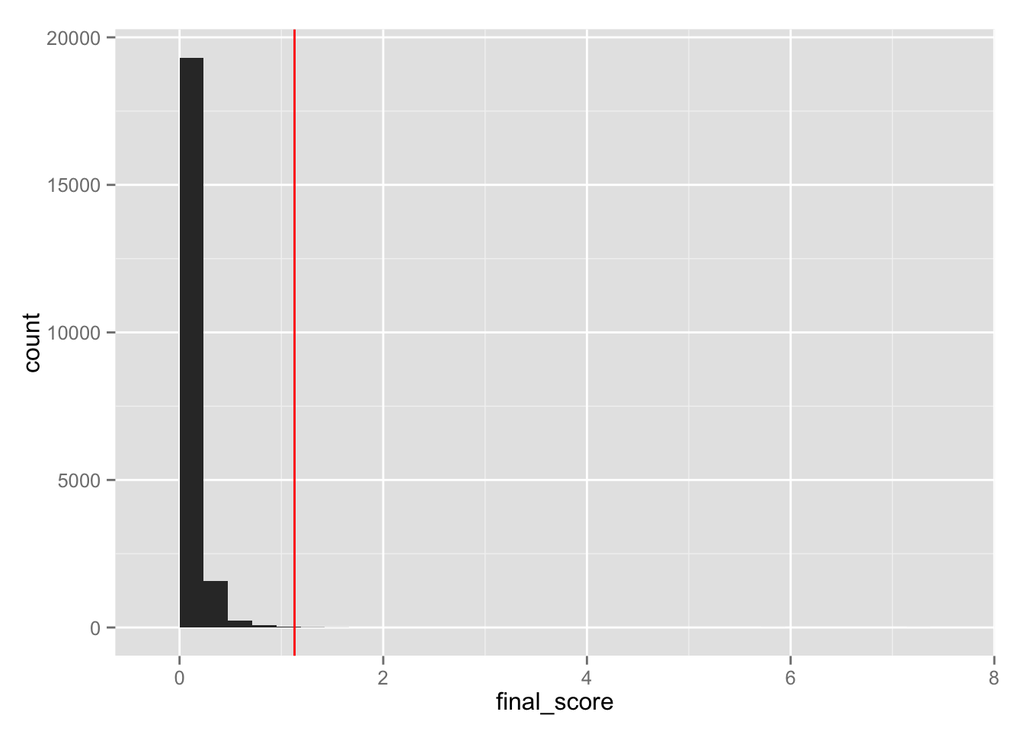

```r
m <- data.frame(min=min(res$final_score))
ggplot() +
  geom_bar(data=output, mapping=aes(x=final_score)) +
  geom_vline(data=res, aes(xintercept=min(final_score)), color='red')
```

A la derecha de la línea roja, están los 15 documentos con los scores más altos. Si la cantidad de documentos cercanos la linea roja por el lado izquierdo es muy grande quiere deicr que no estamos logrando una buena discriminación. Por el contrario, si la distribución tiene una cola muy delgada del lado derecho, realmente estamos obteniendo documentos relevantes.

A continuación, vemos como obtenemos de forma particular las palabras que más contribuyen a nuestro modelo.

```r
best <- function(nmatch = 3, nterm = 5, alpha=.5){
  vq.title <- query.vec.title
  vq.abst <- query.vec.abst

  outlist <- list()

  for(i in 1:nmatch){

    v.j.title <- mat.title[,idx_top_title[i]]
    v.j.abst <- mat.abst[,idx_top_abst[i]]

    v1 <- v.j.title*vq.title
    v2 <- v.j.abst*vq.abst

    top_contrib_title <- order(v1,decreasing=T)
    top_contrib_abst <- order(v2,decreasing=T)

    df.title <- data.frame(term=dictionary_title[top_contrib_title[1:nterm]],
                           score_contrib_title=v1[top_contrib_title[1:nterm]],
                           score_contrib_abst=rep(0,nterm) , stringsAsFactors=F)

    df.abst <- data.frame(term=dictionary_abst[top_contrib_abst[1:nterm]],
                          score_contrib_title=rep(0,nterm),
                          score_contrib_abst=v2[top_contrib_abst[1:nterm]],stringsAsFactors=F)
    df <- rbind(df.title,df.abst)

    df <- cbind(aggregate(score_contrib_title ~ term, data=df, FUN=sum),
                score_contrib_abst=aggregate(score_contrib_abst ~ term, data=df, FUN=sum)[,2])
    df$contrib <- alpha*df$score_contrib_title+(1-alpha)*df$score_contrib_abst

    outlist[[i]] <- df %>%
      filter(contrib>0) %>%
      mutate(rank=i)
  }
  rbind_all(outlist) %>%
    dplyr::select(term,contrib,rank) %>%
    group_by(term) %>%
    summarise(contrib_tot=sum(contrib)) %>%
    arrange(desc(contrib_tot))
}


#best <- best(nmatch = 15, nterm = 5, alpha=.5)

best <- best(nmatch = 15, nterm = length(unique(strsplit(query.limp$content[[1]]$content," ")[[1]])))

kable(head(best,15))
```

| term | contrib_tot |
| --- | --- |
| polar | 6.7330224 |
| volcano | 5.8325663 |
| gilbert | 3.6734728 |
| revers | 3.6029819 |
| upper | 2.6790504 |
| studi | 2.2322970 |
| waiana | 1.8364616 |
| kaena | 1.6662949 |
| gauss | 1.4951931 |
| from | 1.0979129 |
| transist | 0.7032623 |

Finalmente el wordcloud para una visualización mas amigable.

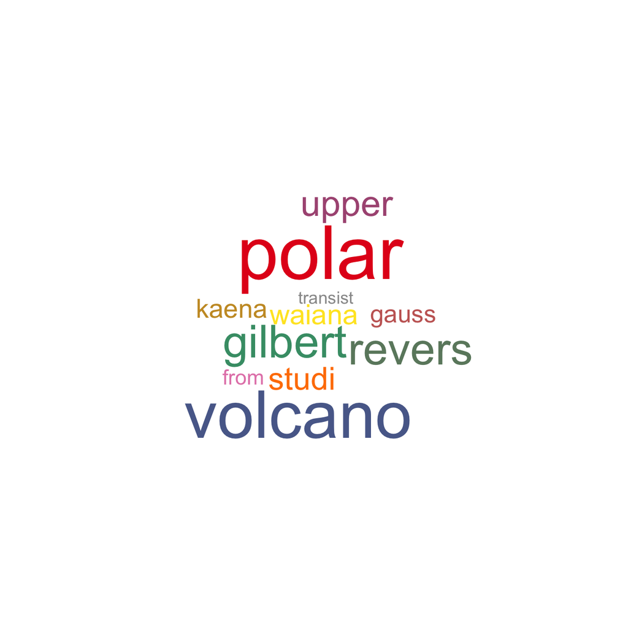

```r
wordcloud(best$term,best$contrib_tot,
          scale=c(5,.7),
          min.freq=0.1,
          ordered.colors=T,
          colors=colorRampPalette(brewer.pal(9,"Set1"))(nrow(best)))
```